# STAT 252 — Chi-Square Experiments

Guided Analysis Workbook

Author

Cal Poly San Luis Obispo

Published

April 15, 2026

# How to Use This Workbook

This workbook covers four experiments organized around two chi-square techniques:

- **Goodness of Fit** (Experiments 4 & 5): Does the observed distribution of a *single* categorical variable match a hypothesized distribution?
- **Test of Independence** (Experiments 6 & 7): Are *two* categorical variables associated, or are they independent?

For each experiment we follow the **SSVA framework**:

1. **State the research question.**
2. **Look at the raw data** in the Google Sheet.
3. **Examine summary statistics** (observed vs. expected counts).
4. **Interpret the visualization.**
5. **Run the analysis** (chi-square test statistic, p-value).
6. **Answer SSVA guiding questions.**
7. **Answer independent conceptual questions.**

**Session code:** `section-8`  
**Class Google Sheet:** [open in new tab](https://docs.google.com/spreadsheets/d/1IzT5bmVMggu83kL6dNwThwvOXybVkt0joSRxu4YJJAY/edit)  
**Report generated:** April 15, 2026 at 11:40 AM

**Tip**

**Before each experiment:** open the class Google Sheet linked above and click the tab for that experiment (`roulette`, `birthmonth`, `coffee`, or `pressure`).

# 1 Experiment 4 — Goodness of Fit: Is the Roulette Wheel Rigged?

## 1.1 Research Question

> **When pooling all students’ roulette spins, does the distribution of outcomes (pockets 1–6) match what we’d expect from a fair wheel?**

## 1.2 Step 1 — Look at the Raw Data

**Note**

First few students’ roulette spin tallies

| Wheel type | 1s | 2s | 3s | 4s | 5s | 6s |
| --- | --- | --- | --- | --- | --- | --- |
| fair | 4 | 2 | 2 | 1 | 3 | 3 |
| fair | 4 | 2 | 2 | 1 | 3 | 3 |
| fair | 4 | 2 | 2 | 1 | 3 | 3 |

## 1.3 Step 2 — Summary Statistics

Observed vs. expected counts across all students’ spins

| Pocket | Observed count | Expected count (if fair) |
| --- | --- | --- |
| 1 | 12 | 7.5 |
| 2 | 6 | 7.5 |
| 3 | 6 | 7.5 |
| 4 | 3 | 7.5 |
| 5 | 9 | 7.5 |
| 6 | 9 | 7.5 |

## 1.4 Step 3 — Visualization

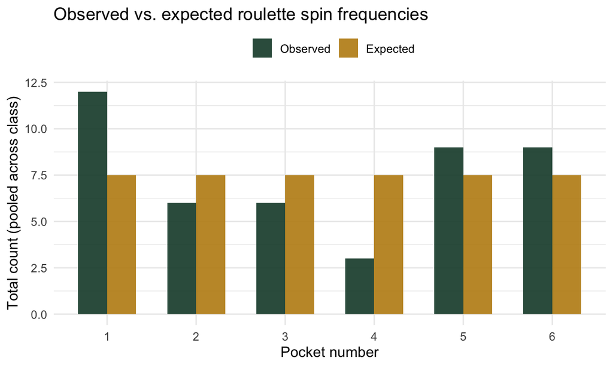

## 1.5 Step 4 — Analysis

Chi-square goodness-of-fit test

| Quantity | Value |
| --- | --- |
| Chi-square statistic (χ²) | 6.6 |
| Degrees of freedom | 5 |
| p-value | 0.2521 |
| Total spins pooled | 45 |

## 1.6 SSVA Guiding Questions — Experiment 4

**Q1.** What single categorical variable are we studying? What are its possible values?

**Click to reveal answer**

The variable is **roulette pocket**, with 6 possible values: 1, 2, 3, 4, 5, 6 (alternating red and black on the wheel).

**Q2.** What is the hypothesized (expected) distribution under the null?

**Click to reveal answer**

Under the null, the wheel is fair, so each pocket has probability 1/6. The expected count for each pocket = (total spins) × (1/6).

**Q3.** Compare the observed and expected bars in the chart. Which face(s) depart most from expectation? What might explain this?

**Click to reveal answer**

Look for the face where the observed bar is tallest relative to its expected bar. If pocket 6 has a noticeably higher observed count, that’s consistent with some students having rigged wheels (biased toward 6). Other pockets may be slightly lower than expected to compensate.

**Q4.** How does the chi-square statistic work? What would a value of 0 mean? What does a large value mean?

**Click to reveal answer**

The chi-square statistic sums $\frac{(\text{observed} - \text{expected})^2}{\text{expected}}$ across all categories. A value of **0** would mean every observed count perfectly matches the expected count — the data fit the hypothesized distribution exactly. A **large** value means the observed counts deviate substantially from what was expected, suggesting the hypothesized distribution is wrong.

**Q5.** Based on the visualization and summary statistics alone, what is your initial conclusion?

**Click to reveal answer**

If the observed and expected bars look roughly equal for all pockets, the data are consistent with fair wheels. If pocket 6 towers above expectation while others dip below, the data suggest the pooled wheel is not fair — the rigged wheels in the mix are pulling the distribution away from uniform.

## 1.7 Independent Conceptual Questions — Experiment 4

**C1.** What is the statistical question?

**Click to reveal answer**

Does the distribution of pooled roulette spin outcomes differ from a uniform distribution where each pocket has probability 1/6?

**C2.** What is the population? What is the sample?

**Click to reveal answer**

**C3.** What is the observational unit?

**Click to reveal answer**

A single roulette spin. Each spin produces one pocket value (1–6).

**C4.** How many variables are in this analysis? Name them.

**Click to reveal answer**

**One** variable: roulette pocket (categorical with 6 levels). Goodness-of-fit tests examine the distribution of a single categorical variable.

**C5.** State the null and alternative hypotheses.

**Click to reveal answer**

$H_0$: The true probability of each face is $p_1 = p_2 = p_3 = p_4 = p_5 = p_6 = 1/6$ (fair wheel).

$H_a$: At least one $p_i \neq 1/6$ (not a fair wheel).

**C6.** How are degrees of freedom calculated for this test?

**Click to reveal answer**

$df = k - 1$ where $k$ is the number of categories. Here $k = 6$, so $df = 5$.

**C7.** What potential confounding factors or design limitations exist?

**Click to reveal answer**

**C8.** Based on the test statistic and p-value, what do you conclude?

**Click to reveal answer**

If p < 0.05, reject $H_0$ — the pooled distribution is significantly different from uniform, consistent with some wheels being rigged. If p ≥ 0.05, fail to reject — the data are consistent with fair wheels (or the rigged wheels didn’t produce enough imbalance to detect with this sample size).

# 2 Experiment 5 — Goodness of Fit: Birth Month Distribution

## 2.1 Research Question

> **Are birth months in our class uniformly distributed across the 12 months of the year?**

## 2.2 Step 1 — Look at the Raw Data

**Note**

**Open the class Google Sheet and click the `birthmonth` tab.** Each row is one student with their birth month. How many total students submitted? Can you eyeball which months are most and least common?

First few rows of the birth month data

| Birth Month |
| --- |
| Feb |
| Apr |
| Mar |

## 2.3 Step 2 — Summary Statistics

Observed vs. expected birth month counts

| Month | Observed | Expected (uniform) |
| --- | --- | --- |
| Jan | 0 | 0.2 |
| Feb | 1 | 0.2 |
| Mar | 1 | 0.2 |
| Apr | 1 | 0.2 |
| May | 0 | 0.2 |
| Jun | 0 | 0.2 |
| Jul | 0 | 0.2 |
| Aug | 0 | 0.2 |
| Sep | 0 | 0.2 |
| Oct | 0 | 0.2 |
| Nov | 0 | 0.2 |
| Dec | 0 | 0.2 |

## 2.4 Step 3 — Visualization

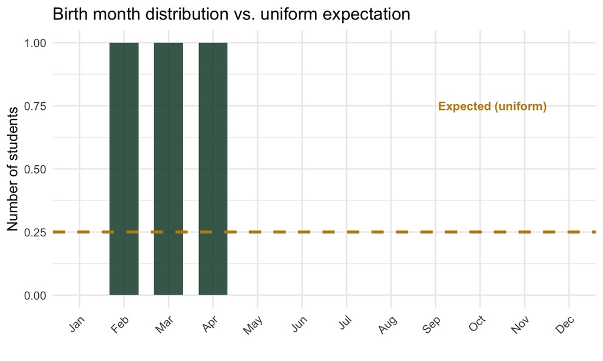

## 2.5 Step 4 — Analysis

Chi-square goodness-of-fit test

| Quantity | Value |
| --- | --- |
| Chi-square statistic (χ²) | 9 |
| Degrees of freedom | 11 |
| p-value | 0.6219 |
| Total students | 3 |

## 2.6 SSVA Guiding Questions — Experiment 5

**Q1.** What single categorical variable are we studying? How many categories does it have?

**Click to reveal answer**

The variable is **birth month** with 12 categories (Jan through Dec).

**Q2.** What is the expected distribution under the null hypothesis?

**Click to reveal answer**

Under $H_0$, births are uniformly distributed across the 12 months, so each month’s expected count = (total students) / 12.

**Q3.** Look at the bar chart. Which months, if any, stand out as having more or fewer students than expected?

**Click to reveal answer**

Compare each bar to the dashed gold line (the expected count). Bars well above the line are months with more births than expected; bars well below have fewer. With a class of ~30 students, even moderate clumpiness is normal by chance — the chi-square test tells us whether the overall departure is more than we’d expect from random variation.

**Q4.** Why might the uniform distribution actually be a poor model for real birth months?

**Click to reveal answer**

In reality, US births show a seasonal pattern: more births in late summer and early fall (August–October), fewer in winter months. This is well-documented in demographic research. A class of 30 may or may not have enough power to detect this real-world departure from uniformity.

**Q5.** Based on SSVA alone, does the distribution look uniform?

**Click to reveal answer**

If most bars are close to the dashed line with only small deviations, the data look roughly uniform. If a few months are clearly overrepresented or underrepresented, the data suggest a non-uniform pattern. But remember — with small expected counts per cell (~2-3 students per month for a class of 30), large visual fluctuations are normal even under a truly uniform distribution.

## 2.7 Independent Conceptual Questions — Experiment 5

**C1.** What is the statistical question?

**Click to reveal answer**

Is the distribution of birth months in our class consistent with a uniform distribution where each month has probability 1/12?

**C2.** What is the population? What is the sample?

**Click to reveal answer**

**Population:** all Cal Poly students who could plausibly take this course. **Sample:** the students in this section who submitted their birth month.

**C3.** What is the observational unit?

**Click to reveal answer**

An individual student.

**C4.** State the null and alternative hypotheses.

**Click to reveal answer**

$H_0$: $p_{\text{Jan}} = p_{\text{Feb}} = \dots = p_{\text{Dec}} = 1/12$ (births are uniformly distributed).

$H_a$: At least one month’s probability differs from 1/12.

**C5.** What are the degrees of freedom, and how are they calculated?

**Click to reveal answer**

$df = k - 1 = 12 - 1 = 11$.

**C6.** What is a potential concern with expected cell counts here? Does it apply?

**Click to reveal answer**

**C7.** Is this an experiment or an observational study?

**Click to reveal answer**

**Observational study.** Students aren’t assigned a birth month — it’s a pre-existing characteristic. We’re just observing and recording it.

**C8.** Based on the test statistic and p-value, what do you conclude?

**Click to reveal answer**

If p < 0.05, reject $H_0$ — the distribution of birth months in our class is significantly different from uniform. If p ≥ 0.05, fail to reject — the data are consistent with a uniform distribution. Note: failing to reject doesn’t prove births *are* uniform — we may just lack power with a small sample.

# 3 Experiment 6 — Test of Independence: Coffee Drink & Where You’re From

## 3.1 Research Question

> **Is the kind of coffee drink students prefer associated with whether they grew up on the coast or inland?**

```
> *No data found for the 'coffee' experiment in session `section-8`. Skipping.*
```

## 3.2 Step 1 — Look at the Raw Data

**Note**

**Open the class Google Sheet and click the `coffee` tab.** Each row records one student’s hometown type (Coast or Inland) and their go-to coffee drink. Browse — do you see any pattern?

## 3.6 SSVA Guiding Questions — Experiment 6

**Q1.** What two categorical variables are we analyzing, and what are the dimensions of the table?

**Answer**

**Origin** (2 levels: Coast, Inland) and **Drink** (4 levels: Black, Latte, Sweet, None). The contingency table is **2 × 4**.

**Q2.** If origin and drink were independent, what would the bar chart look like?

**Answer**

The proportional breakdown of drinks would be identical for Coast and Inland students. The four colored bars would have the same heights in both groups.

**Q3.** Which cells depart most from expected counts? What does that tell you?

**Answer**

Cells where observed ≫ expected are over-represented combinations; observed ≪ expected are under-represented. For example, if Coast × Latte has observed = 9 but expected = 5, that suggests coastal students disproportionately favor lattes.

## 3.7 Independent Conceptual Questions — Experiment 6

**C1.** State the hypotheses.

**Answer**

$H_0$: Origin and drink preference are **independent**. $H_a$: They are **not independent** (there is an association).

**C2.** Degrees of freedom?

**Answer**

$df = (r-1)(c-1) = (2-1)(4-1) = 3$.

**C3.** Experiment or observational study? Can we conclude causation?

**Answer**

**Observational.** Neither variable is assigned. Even if we reject $H_0$, we can only claim association — not that growing up on the coast *causes* people to drink lattes. Possible confounders: family income, urban vs. rural upbringing, exposure to cafe culture.

**C4.** Based on the test statistic and p-value, what do you conclude?

**Answer**

If p < 0.05, reject $H_0$ — there is a statistically significant association between hometown type and coffee drink. If p ≥ 0.05, fail to reject — the data are consistent with independence.

# 4 Experiment 7 — Test of Independence: Pressure Test (Stress & Performance)

## 4.1 Research Question

> **Does students’ self-reported stress level predict how well they actually perform on a fast-paced reaction game?**

```
> *No data found for the 'pressure' experiment in session `section-8`. Skipping.*
```

## 4.2 How Performance Categories Are Assigned

After the 30-second reaction game, each student’s **score** (number of correct taps) and **accuracy** (correct ÷ total attempts) are combined into a single performance category using the following rubric:

| Category | Score threshold | Accuracy threshold | Plain-English meaning |
| --- | --- | --- | --- |
| **High** | ≥ 16 correct | ≥ 70% | Fast *and* accurate — both conditions must be true |
| **Medium** | ≥ 8 correct | ≥ 55% | Reasonably fast and reasonably accurate — both conditions must be true |
| **Low** | Below Medium thresholds | — | Missed at least one of the Medium conditions |

**Tip**

**Why two conditions?** Speed alone can be gamed by tapping randomly; accuracy alone can be faked by tapping slowly. Requiring *both* score and accuracy to clear the bar ensures the category reflects genuine performance under pressure.

## 4.3 Step 1 — Look at the Raw Data

**Note**

**Open the class Google Sheet and click the `pressure` tab.** Each row records one student’s self-reported stress level *before* the game and their measured performance category *during* the game (plus their raw score, accuracy, and average reaction time).

## 4.7 SSVA Guiding Questions — Experiment 7

**Q1.** What’s special about how the two variables in this experiment were measured?

**Answer**

Stress is **self-reported** (subjective) and performance is **objectively measured** by the game (score, accuracy, reaction time combined into a category). One variable is what students *think* about themselves; the other is what they actually *did*. This contrast is what makes the test interesting.

**Q2.** Dimensions of the contingency table and degrees of freedom?

**Answer**

3 × 3 table (Low/Med/High stress × Low/Med/High performance), so $df = (3-1)(3-1) = 4$.

**Q3.** If stress and performance were independent, what would the visualization show?

**Answer**

The proportional breakdown of performance categories would be identical across the three stress groups. The bars would look the same regardless of stress level.

**Q4.** What story would you expect intuitively? Does the data agree?

**Answer**

The intuitive prediction is that high-stress students would underperform (more in the Low performance category) and low-stress students would perform better. But the actual data may surprise you — some research suggests *moderate* stress actually helps performance, and people often misjudge how stressed they are. Compare your prediction to what the bars actually show.

## 4.8 Independent Conceptual Questions — Experiment 7

**C1.** State the hypotheses.

**Answer**

$H_0$: Self-reported stress and game performance are **independent**. $H_a$: They are **not independent** (associated).

**C2.** Is this an experiment or an observational study? Justify carefully — there’s a subtlety.

**Answer**

This is **observational** for the relationship being tested. Stress is not randomly assigned — students arrive in class with whatever stress level they have. The game is a *measurement instrument*, not a treatment. So even though we’re collecting performance data through an active task, we’re observing the natural relationship between pre-existing stress and performance, not manipulating either one.

**C3.** What confounders could explain any association we find?

**Answer**

Sleep, caffeine, video game experience, hand-eye coordination, time of day, mood, recent meals. Notably, students who play a lot of fast-paced games may perform well *and* report low stress, but the gaming experience (not the stress) drives performance.

**C4.** Based on the test, what do you conclude?

**Answer**

If p < 0.05, reject $H_0$ — there’s a statistically significant association between self-reported stress and measured game performance. If p ≥ 0.05, fail to reject — stress (as self-reported) is not predictive of performance in this sample. Either result is interesting to discuss in context.